# Part_I_exploration

##### Part I - Loan Data from Prosper DATASET

## Introduction

This data set contains 113,937 loans with 81 variables on each loan, including loan amount, borrower rate (or interest rate), current loan status, borrower income, and many others.

## Preliminary Wrangling

```python
# import all packages and set plots to be embedded inline
import numpy as np
import pandas as pd
import matplotlib.pyplot as plt
import seaborn as sb

%matplotlib inline
```

```python
# loading dataset
loan_data =  pd.read_csv('prosperLoanData.csv')
```

```python
loan_data.head(5)
```

|  | ListingKey | ListingNumber | ListingCreationDate | CreditGrade | Term | LoanStatus | ClosedDate | BorrowerAPR | BorrowerRate | LenderYield | ... | LP_ServiceFees | LP_CollectionFees | LP_GrossPrincipalLoss | LP_NetPrincipalLoss | LP_NonPrincipalRecoverypayments | PercentFunded | Recommendations | InvestmentFromFriendsCount | InvestmentFromFriendsAmount | Investors |
| --- | --- | --- | --- | --- | --- | --- | --- | --- | --- | --- | --- | --- | --- | --- | --- | --- | --- | --- | --- | --- | --- |
| 0 | 1021339766868145413AB3B | 193129 | 2007-08-26 19:09:29.263000000 | C | 36 | Completed | 2009-08-14 00:00:00 | 0.16516 | 0.1580 | 0.1380 | ... | -133.18 | 0.0 | 0.0 | 0.0 | 0.0 | 1.0 | 0 | 0 | 0.0 | 258 |
| 1 | 10273602499503308B223C1 | 1209647 | 2014-02-27 08:28:07.900000000 | NaN | 36 | Current | NaN | 0.12016 | 0.0920 | 0.0820 | ... | 0.00 | 0.0 | 0.0 | 0.0 | 0.0 | 1.0 | 0 | 0 | 0.0 | 1 |
| 2 | 0EE9337825851032864889A | 81716 | 2007-01-05 15:00:47.090000000 | HR | 36 | Completed | 2009-12-17 00:00:00 | 0.28269 | 0.2750 | 0.2400 | ... | -24.20 | 0.0 | 0.0 | 0.0 | 0.0 | 1.0 | 0 | 0 | 0.0 | 41 |
| 3 | 0EF5356002482715299901A | 658116 | 2012-10-22 11:02:35.010000000 | NaN | 36 | Current | NaN | 0.12528 | 0.0974 | 0.0874 | ... | -108.01 | 0.0 | 0.0 | 0.0 | 0.0 | 1.0 | 0 | 0 | 0.0 | 158 |
| 4 | 0F023589499656230C5E3E2 | 909464 | 2013-09-14 18:38:39.097000000 | NaN | 36 | Current | NaN | 0.24614 | 0.2085 | 0.1985 | ... | -60.27 | 0.0 | 0.0 | 0.0 | 0.0 | 1.0 | 0 | 0 | 0.0 | 20 |

5 rows × 81 columns

```python
# Changing DataTypes
cat_dict = {'LoanStatus' : [ 'Current','Completed','FinalPaymentInProgress','Past Due (1-15 days)','Past Due (31-60 days)','Past Due (61-90 days)','Past Due (91-120 days)','Past Due (16-30 days)','Past Due (>120 days)','Cancelled','Chargedoff','Defaulted'],
                    'EmploymentStatus' : ['Employed','Full-time','Self-employed','Not available','Other','Part-time','Not employed','Retired'],
                    'ListingCategory (numeric)' : ['0','1','2','3','4','5','6','7','8','9','10','11','12','13','14','15','16','17','18','19','20'],
                    'IncomeRange' : ['$100,000+','$75,000-99,999','$50,000-74,999','$25,000-49,999','$0','$1-24,999','Not employed','Not displayed']}

for var in cat_dict:
    cat_ordered = pd.api.types.CategoricalDtype(ordered = True,
                                               categories = cat_dict[var])
    loan_data[var] = loan_data[var].astype(cat_ordered)
```

```python
# Changing datatypes
convert_dict = {'BorrowerState' : str, 'Occupation' : str,'IsBorrowerHomeowner': bool, 'CurrentlyInGroup' : bool}

loan_data = loan_data.astype(convert_dict)
```

### What is the structure of your dataset?

> This data set contains 113,937 loans with 81 variables on each loan, including loan amount, borrower rate (or interest rate), current loan status, borrower income, and many others

### What features in the dataset do you think will help support your investigation into your feature(s) of interest?

> I think factor like the employement status and duration of employment of the borrower will influence the APR and interest rate.Also The history of the borrower in paying loans will influence the outcome of a current loan

## Univariate Exploration

I will start but exploring the distribution of the state of the loans across the dataset

```python
def Countplot(df, xvar, huevar=None, color=0, palette=None, order=None):
  #set plot dimentions
  plt.figure(figsize = [14,6])
  #plot
  sb.countplot(data=df, x=xvar, hue=huevar, color=sb.color_palette()[color], palette=palette, order=order, edgecolor='black')
  #clean up variable names
  xvar = xvar.replace("_"," ")
  if huevar:
      huevar = huevar.replace("_"," ")
  #add title and format it
  plt.title(f"Distribution of Loan Data: {xvar} {'by' if huevar else ''} {huevar if huevar else ''}" .title(), fontsize=14, weight='bold')
  #add x label and format it
  plt.xlabel(xvar.title(), fontsize=10, weight='bold')
  #add y label and format it
  plt.ylabel('Frequency', fontsize=10, weight='bold')
  plt.xticks(rotation=55);
```

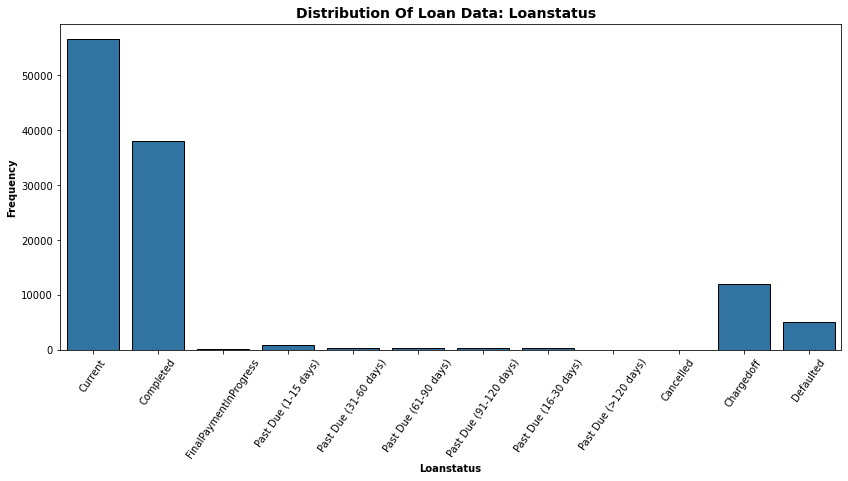

```python
Countplot(loan_data,'LoanStatus', huevar=None, color=0, palette=None, order=None);
```

Next up, The distribution of Employment Status throughout the dataset

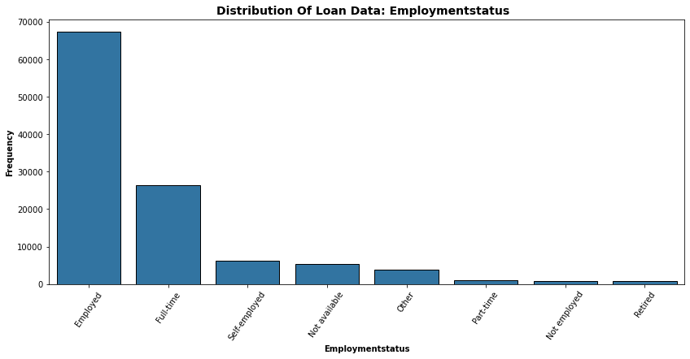

```python
Countplot(loan_data,'EmploymentStatus', huevar=None, color=0, palette=None, order=None);
```

The Employment Status of borrowers across shows that most of the borrowers are Employed. With the least being the retired below 1000.

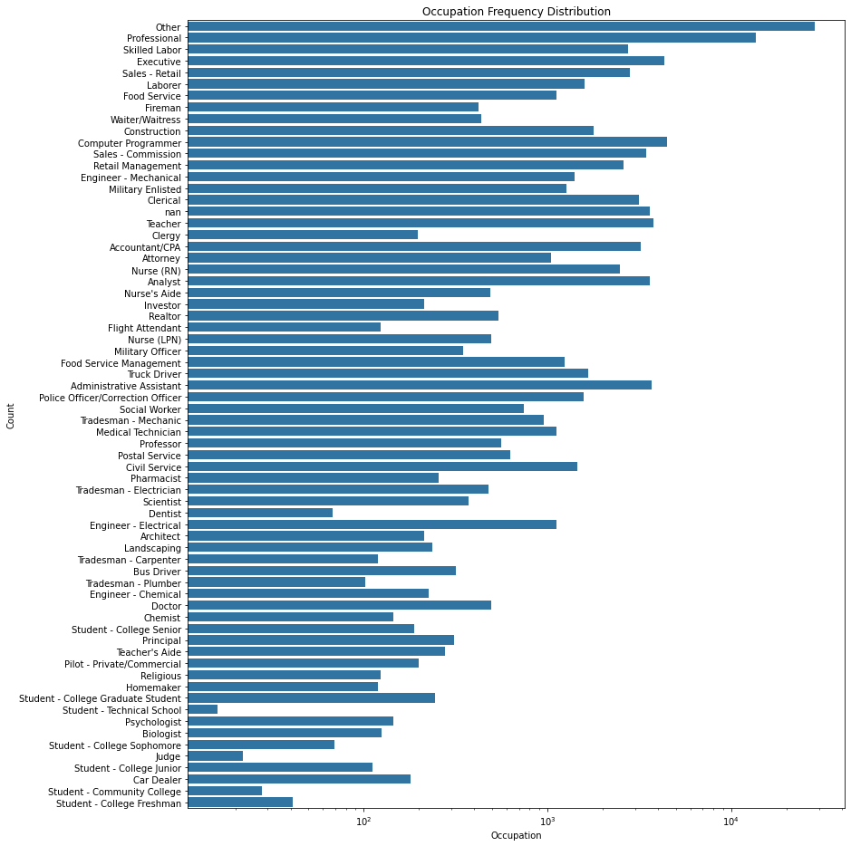

```python
plt.figure(figsize=[13,16]);
sb.countplot(data = loan_data, y= 'Occupation', color = base_color);
plt.title('Occupation Frequency Distribution');
plt.ylabel('Count');
plt.xlabel('Occupation');
plt.xscale('log');
```

Next let me expore the BorrowerAPR and the BorrowerRate to see the districution over the dataset

```python
#creating a fuction that plots seaborn countplots
def Countplot(df, xvar, huevar=None, color=0, palette=None, order=None):
  #set plot dimentions
  plt.figure(figsize = [14,6])
  #plot
  sb.countplot(data=df, x=xvar, hue=huevar, color=sb.color_palette()[color], palette=palette, order=order, edgecolor='black')
  #clean up variable names
  xvar = xvar.replace("_"," ")
  if huevar:
      huevar = huevar.replace("_"," ")
  #add title and format it
  plt.title(f"Distribution of bike rides: {xvar} {'by' if huevar else ''} {huevar if huevar else ''}" .title(), fontsize=14, weight='bold')
  #add x label and format it
  plt.xlabel(xvar.title(), fontsize=10, weight='bold')
  #add y label and format it
  plt.ylabel('Frequency', fontsize=10, weight='bold')
```

```python
def histd(df, xvar, bins):
    #set plot dimensions
    plt.figure(figsize = [14,8])
    #plot
    plt.hist(data =  df, x = xvar, bins = bins)
    #clean up variable names
    xvar = xvar.replace("_"," ")
    #title and format
    plt.title(f"Distribution of Loan's: {xvar}".title(), fontsize=14, weight='bold')
    #add x label and format it
    plt.xlabel(xvar.title(), fontsize=10, weight='bold')
    #add y label and format it
    plt.ylabel('Frequency', fontsize=10, weight='bold')
    #adding ticks
    plt.xticks([0.0, 0.1, 0.2, 0.3, 0.4, 0.5], ['0', '10' ,'20', '30', '40', '50'])
```

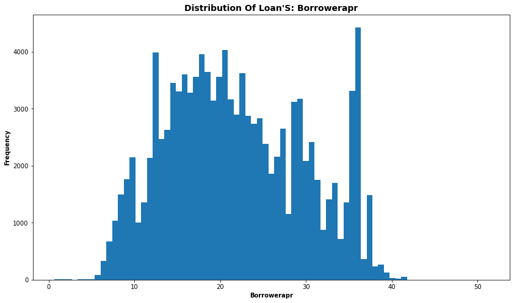

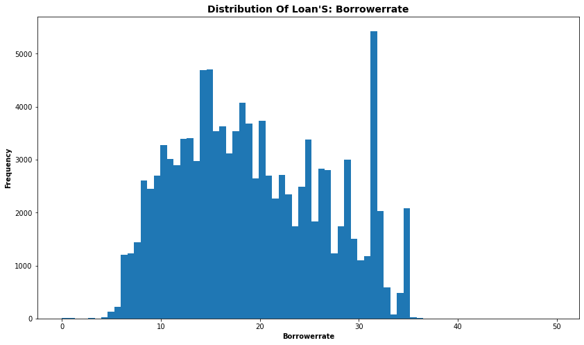

```python
#ploting the distribution borrower APR
histd(loan_data, 'BorrowerAPR', bins = 75)
#Plotting the distribution borrower rate
histd(loan_data, 'BorrowerRate', bins = 75);
```

Using a bin of 75 for both histograms I observed the following

- For the Borrow APR we had a peaks at about 12-13% and so at 36 - 38%. We will have to look into these better to understand whu most loans had the APR set at those rates
- For the Borrowers rate noticed a rise form 5% going up with noticable peaks at 15-16%, with the highest peaks at 32-33%. More study can be done to undertand why this happens

Let us take a look at the distribution the Borrowers' APR and interest rate of Completed, charged off and defaulted.

```python
loan_data.LoanStatus.value_counts()
```

```
Current                   56576
Completed                 38074
Chargedoff                11992
Defaulted                  5018
Past Due (1-15 days)        806
Past Due (31-60 days)       363
Past Due (61-90 days)       313
Past Due (91-120 days)      304
Past Due (16-30 days)       265
FinalPaymentInProgress      205
Past Due (>120 days)         16
Cancelled                     5
Name: LoanStatus, dtype: int64
```

```python
Current = loan_data.query('LoanStatus == "Current"')
Completed = loan_data.query('LoanStatus == "Completed"')
Chargedoff = loan_data.query('LoanStatus == "Chargedoff"')
Defaulted = loan_data.query('LoanStatus == "Defaulted"')
```

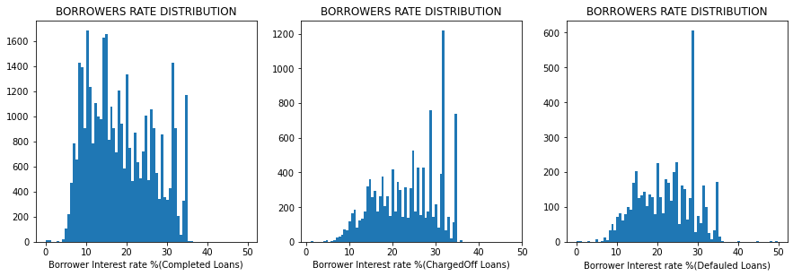

```python
# the Borrowers' INTEREST RATE distribution for Completed, ChargedOff and Defaulted
plt.figure(figsize= [15,10])
plt.subplot(2, 3, 1)
plt.hist(data = Completed, x = 'BorrowerRate', bins = 75)
plt.xlabel('Borrower Interest rate %(Completed Loans)')
plt.title('BORROWERS RATE DISTRIBUTION')
plt.xticks([0.0, 0.1, 0.2, 0.3, 0.4, 0.5], ['0', '10' ,'20', 30, 40, 50])


plt.subplot(2, 3, 2)
plt.hist(data = Chargedoff, x = 'BorrowerRate', bins = 75)
plt.xlabel('Borrower Interest rate %(ChargedOff Loans)')
plt.title('BORROWERS RATE DISTRIBUTION')
plt.xticks([0.0, 0.1, 0.2, 0.3, 0.4, 0.5], ['0', '10' ,'20', 30, 40, 50])

plt.subplot(2, 3 ,3)
plt.hist(data = Defaulted, x = 'BorrowerRate', bins = 75)
plt.xlabel('Borrower Interest rate %(Defauled Loans)')
plt.title('BORROWERS RATE DISTRIBUTION')
plt.xticks([0.0, 0.1, 0.2, 0.3, 0.4, 0.5], ['0', '10' ,'20', 30, 40, 50]);
```

We will look at the effect of being a homeowner has on the issuance of the loan

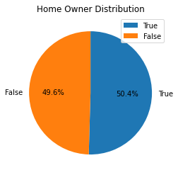

```python
sorted_counts = loan_data['IsBorrowerHomeowner'].value_counts()
plt.pie(sorted_counts,labels = sorted_counts.index, startangle = 90, counterclock = False, autopct='%1.1f%%')
plt.title("Home Owner Distribution")
plt.legend();
```

The pie chart shows there was very little impact on the issuance of loans on the factor of the borrower being a home owner

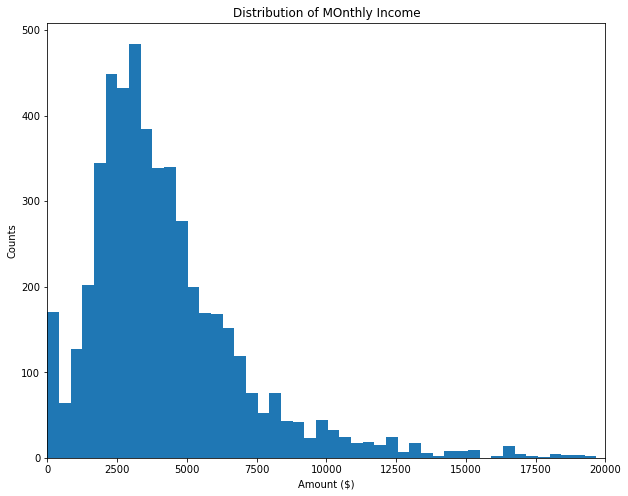

```python
plt.figure(figsize = [10,8])
plt.hist(data = Defaulted, x = 'StatedMonthlyIncome', bins = 140)
plt.xlim(0,20000)
plt.xlabel('Amount ($)')
plt.ylabel('Counts')
plt.title('Distribution of MOnthly Income');
```

The dustribution pf the Income has a peak at 3000 dollars and from goes down meaaning less people earning more than 3000 dollars per month.

### Discuss the distribution(s) of your variable(s) of interest. Were there any unusual points? Did you need to perform any transformations?

> I deemed the distriutions on the Borrowers' APR and interest rate didn't have too many outliers so there wasn't a need for transfromation. Both distributions show a bi-model distribution.

### Of the features you investigated, were there any unusual distributions? Did you perform any operations on the data to tidy, adjust, or change the form of the data? If so, why did you do this?

> No Tiding was done here because I deem my dataset clean. but I did actualy created sub dataset to address some issues under differebt situations.

## Bivariate Exploration

> In this section, investigate relationships between pairs of variables in your data. Make sure the variables that you cover here have been introduced in some fashion in the previous section (univariate exploration).

```python
categoric_varS = ['LoanStatus','EmploymentStatus','IncomeRange']
numeric_vars = ['BorrowerAPR', 'BorrowerRate','LenderYield']
```

We will look at a relationship between all the BorrowerAPR, BorrowerRate and LenderYield

```
loan_data.shape= (113937, 81)
loan_data_samp.shape= (500, 81)
```

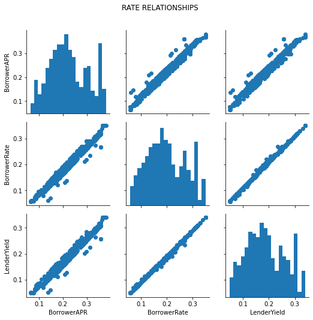

```python
# plot matrix: sample 500 diamonds so that plots are clearer and they render faster
print("loan_data.shape=",loan_data.shape)
loan_data_samp = loan_data.sample(n=500, replace = False)
print("loan_data_samp.shape=",loan_data_samp.shape)

g = sb.PairGrid(data = loan_data_samp, vars = numeric_vars)
g = g.map_diag(plt.hist, bins = 20);
g.map_offdiag(plt.scatter)
g.fig.subplots_adjust(top=0.9) # adjust the Figure in rp
g.fig.suptitle('RATE RELATIONSHIPS');
```

The relationship between the rates are linear which shows a positive correlations between them overall. Let us look relationship of the Borrower's Rate and Borrower's APR

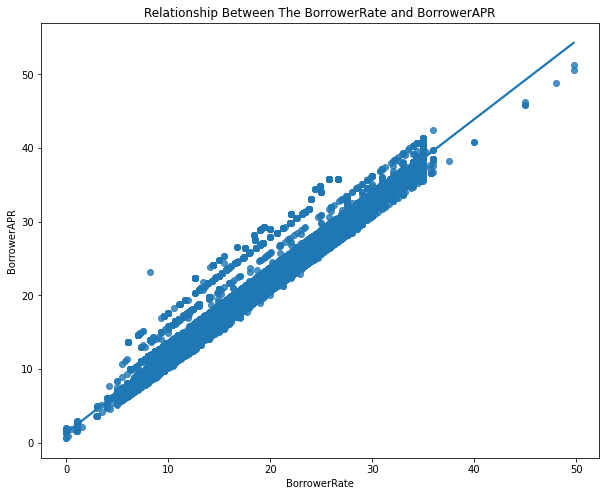

```python
plt.figure(figsize = [10,8])
sb.regplot(data = loan_data, x = 'BorrowerRate', y = 'BorrowerAPR')
plt.yticks([0.0,0.1,0.2,0.3,0.4,0.5],[0,10,20,30,40,50])
plt.xticks([0.0,0.1,0.2,0.3,0.4,0.5],[0,10,20,30,40,50])
plt.title('Relationship Between The BorrowerRate and BorrowerAPR');
```

Next we will look at some other relationships between different variables in our dataset

[figure not shown]

```python
loan_vars = ['BorrowerRate', 'LenderYield','EstimatedEffectiveYield','EstimatedLoss','EstimatedReturn']
g= sb.PairGrid(data = loan_data, vars = loan_vars)
g.map_diag(plt.hist)
g.map_offdiag(plt.scatter)
g.fig.suptitle('Correlation of BorrowerRate,LenderYield,Availble Bank card credit,StateMonthlyIncome and the Loan Original amount', size = 16)
g.fig.subplots_adjust(top = .9);
```

The Relationship between the BorrowerRate and BorrowerAPR is very positive.

```
Next we will look at the relationship with Of The EmploymentStatus and the BorrowerRate
```

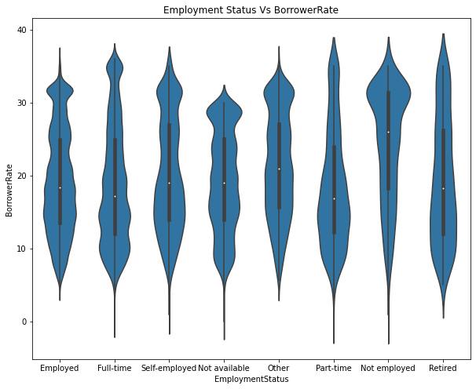

```python
plt.figure(figsize = [10,8])
sb.violinplot(data=loan_data, x='EmploymentStatus', y='BorrowerRate', color=base_color)
plt.yticks([0.0,0.1,0.2,0.3,0.4],[0,10,20,30,40])
plt.title('Employment Status Vs BorrowerRate');
```

We can see that The Not-Employed have a higher median followed by the Others.

```
The next plot will show the a bivariate plot showing a relationship between the The employment status and the homeowner metric
```

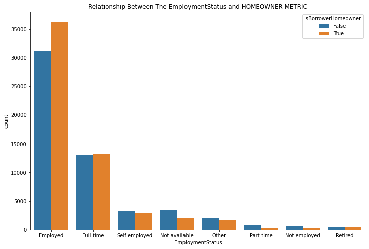

```python
plt.figure(figsize = [12, 8])
sb.countplot(data = loan_data, x = 'EmploymentStatus', hue = 'IsBorrowerHomeowner')
plt.title('Relationship Between The EmploymentStatus and HOMEOWNER METRIC');
```

```
Next we wull look at the relationship between the Lender Yield and BorrowerRate Below
```

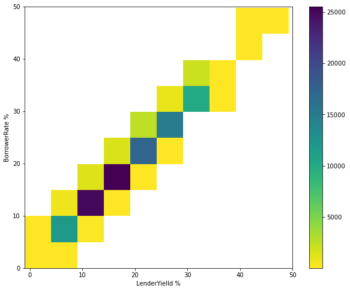

```python
plt.figure(figsize=[10,8])
# bins_x = np.arange(00.006530, loan_data['BorrowerAPR'].max()+.09, 0.01)
# bins_y = np.arange(-0.010000, loan_data['LenderYield'].max()+.09, 0.01)
plt.hist2d(data = loan_data, x = 'LenderYield', y = 'BorrowerRate',cmin=0.5, cmap='viridis_r')
plt.colorbar()
plt.yticks([0.0,0.1,0.2,0.3,0.4,0.5],[0,10,20,30,40,50])
plt.xticks([0.0,0.1,0.2,0.3,0.4,0.5],[0,10,20,30,40,50])
plt.xlabel('LenderYielld %')
plt.ylabel('BorrowerRate %');
```

Here we observe that most of the rates that have highest frequencies were between the 10 % and 20 % rates

```
Next we will look at the relationship between the salary range and if the Borrower was in a group
```

```python
loan_data['IncomeRange'].value_counts()
```

```
$25,000-49,999    32192
$50,000-74,999    31050
$100,000+         17337
$75,000-99,999    16916
Not displayed      7741
$1-24,999          7274
Not employed        806
$0                  621
Name: IncomeRange, dtype: int64
```

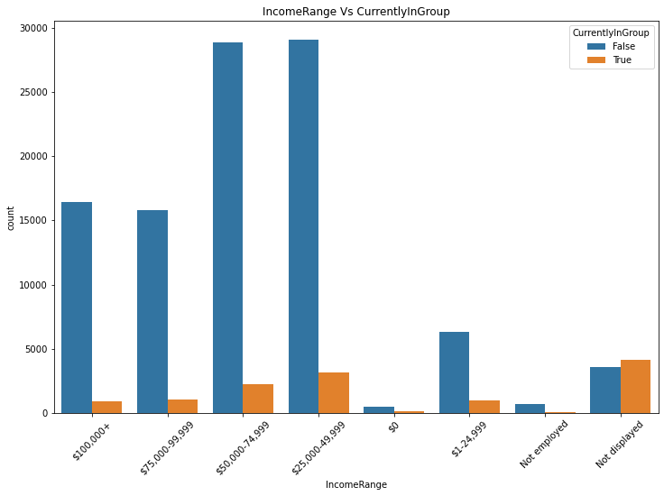

```python
plt.figure(figsize = [12, 8])
sb.countplot(data = loan_data, x = 'IncomeRange', hue = 'CurrentlyInGroup')
plt.title("IncomeRange Vs CurrentlyInGroup")
plt.xticks(rotation=45);
```

From the graph we could see that most peolple were not in the Groups so it is unlikely that The borrower being in a group had an influence on the loans.

### Talk about some of the relationships you observed in this part of the investigation. How did the feature(s) of interest vary with other features in the dataset?

```
The Borrower's rate and APR were linear which a positive correlation between both variables. I didn't use a log scale here because I deemed the two scales being identical already.
The relationship between Employment Status and the borrower rate showed a distribution that was diversely ditribution through out other employment statuses.
The next was the relationship with between the state of the employment and the factor a borrower being a home owner. this shows for the employed and full time status employed they had a slighly highnumber of people who owned home than those who didn't.
```

Also looking at the last I could see the factor of a borrower being in a group had little to no effect on the salary bracket of the borrower. It shows that as the Borrower's salary increase less likely were they in a group.

### Did you observe any interesting relationships between the other features (not the main feature(s) of interest)?

> I observed the Borrower's RATE and APR together with the LenderYield I think more exploration should be done on these feature to get more insight into the dependents of these features

## Multivariate Exploration

Here we will look at the realtiooship between the Employment Status, the income range and their home owner status

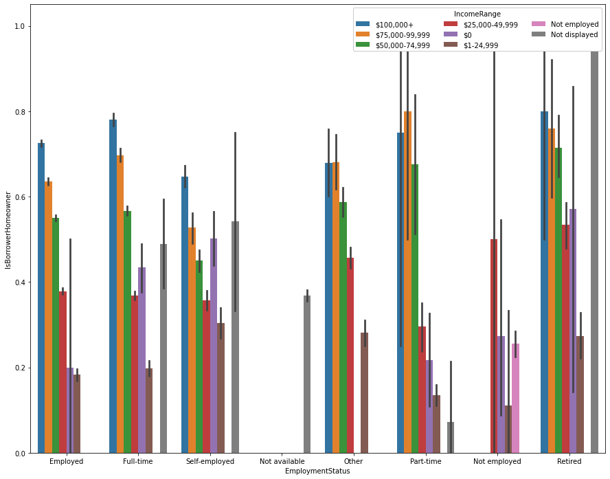

```python
plt.figure(figsize = [15,12])
ax = sb.barplot(data = loan_data, x = 'EmploymentStatus', y = 'IsBorrowerHomeowner', hue = 'IncomeRange')
ax.legend(loc = 1, ncol = 3, framealpha = 1, title = 'IncomeRange');
```

We can look deeper into these considering only Employed in records

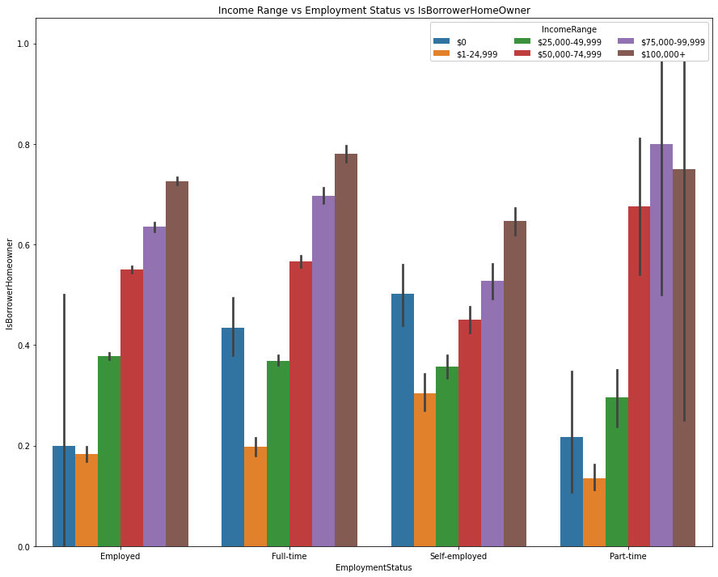

```python
loan_data_earning = loan_data.query('IncomeRange == ["$0","$1-24,999","$25,000-49,999","$50,000-74,999","$75,000-99,999","$100,000+"] and EmploymentStatus == ["Employed","Full-time","Self-employed","Part-time"]')

IncomeRange = ["$0","$1-24,999","$25,000-49,999","$50,000-74,999","$75,000-99,999","$100,000+"]
EmploymentStatus = ['Employed','Full-time','Self-employed','Part-time']
#IncomeRange
cat_ordered = pd.api.types.CategoricalDtype(ordered = True,
                                               categories = IncomeRange)
loan_data_earning['IncomeRange'] = loan_data_earning['IncomeRange'].astype(cat_ordered)

#employmentstatus
cat_ordered1 = pd.api.types.CategoricalDtype(ordered = True,
                                               categories = EmploymentStatus)
loan_data_earning['EmploymentStatus'] = loan_data_earning['EmploymentStatus'].astype(cat_ordered1)
#
plt.figure(figsize = [15,12])
ax = sb.barplot(data = loan_data_earning ,x = 'EmploymentStatus', y = 'IsBorrowerHomeowner', hue = 'IncomeRange')
ax.legend(loc = 1, ncol = 3, framealpha = 1, title = 'IncomeRange')
ax.set_title('Income Range vs Employment Status vs IsBorrowerHomeOwner');
```

### Were there any interesting or surprising interactions between features?

I didn't really see anything new. It just goes back to Reinforce the statement "Money answers all things" which in this case means the more moeny you earn the more guarantee you have to get a loan.